# Chapter 4, Analysis Assigment 4

### Pairwise plots with k-means and two cluster centers

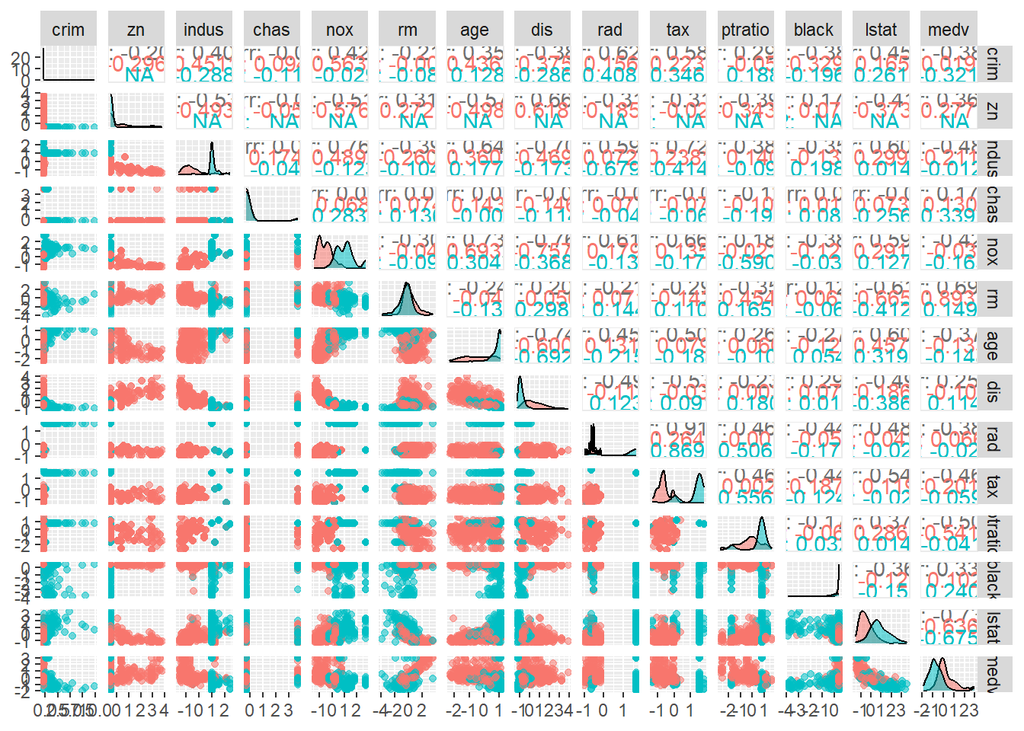

```r
# ggpairs seems to give nicer looking graphs
km_ggpairs <- ggpairs(Boston_scaled2, aes(color=as.factor(km$cluster), alpha = 0.5))
print(km_ggpairs, progress = F)
```

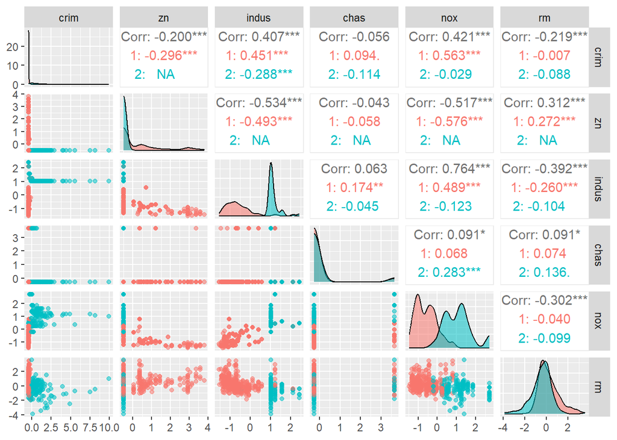

```r
ggpairs(Boston_scaled2, columns=1:6, aes(color=as.factor(km$cluster), alpha = 0.5))
```

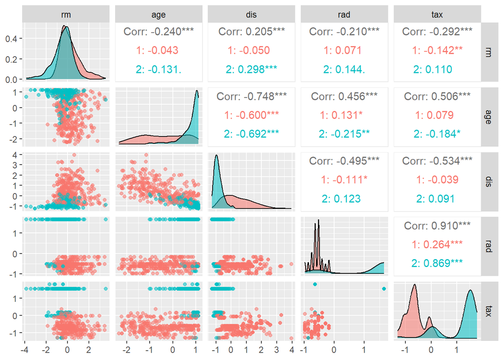

```r
ggpairs(Boston_scaled2, columns=6:10, aes(color=as.factor(km$cluster), alpha = 0.5))
```

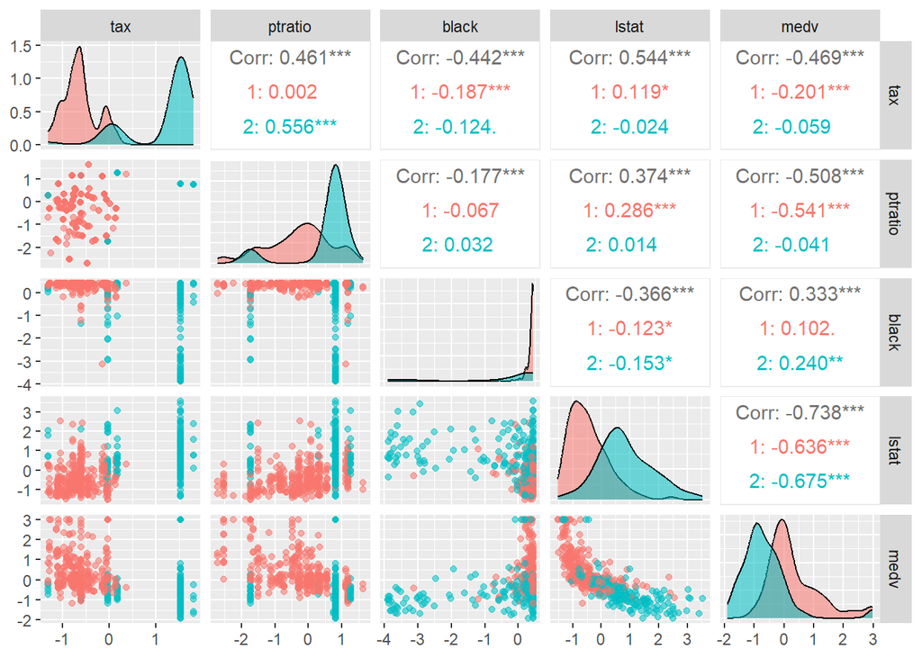

```r
ggpairs(Boston_scaled2, columns=10:14, aes(color=as.factor(km$cluster), alpha = 0.5))
```

The plot with all the pairs is nice in that way that all pairs are there, however, it’s really cramped and there ain’t much of a chance to see the correlations. Nevertheless, there’s some information to be gathered.

**Good separation with two classes can be seen in variables:**

- indus = proportion of non-retail business acres per town.
- nox = nitrogen oxides concentration (parts per 10 million).
- tax = full-value property-tax rate per $10,000.

**A resonable good separation with two classes in variables:**

- pratio = pupil-teacher ratio by town.
- lstat = lower status of the population (percent).
- medv (some separation) = median value of owner-occupied homes in $1000s.
- rad = index of accessibility to radial highways.

**No separation between two classes in variables:**

- zn = proportion of residential land zoned for lots over 25,000 sq.ft.
- chas = Charles River dummy variable (= 1 if tract bounds river; 0 otherwise).
- rm = average number of rooms per dwelling.
- black = $1000 \times (B_k−0.63)^2$, where $B_k$ is the proportion of blacks by town.

I think the best clustering with the two cluster centers can be seen in tax variable. It would seem that in Boston there are those who have lots of property to tax and those who don’t have. The middle is kinda empty. Also, there seems to be places with high non-retail businesses and some places with low number.

When looking at the correlations most are low.

- tax vs. rad correlate highly in cluster no $2$ $r=0.869$
- rm vs. medv correlate highly in cluster no $1$ $r=0.893$

It was seen earlier already that the tax and rad correlated highly. Perhaps this has to do with some highways been close to some expensive areas.